# US Top Income Share 2014

coop711

Sys.Date()

### Data Preparation

준비한 자료는 E. Saez 교수의 홈페이지에 있는 TabFig2014prel.xls 인데 이를 약간의 작업을 거쳐 R에서 불러들이기 편하게 고쳐놓았다.

```r
options(digits=2)
library(xlsx)
load("US_top_income_share_2014.rda")
# US.top.income.shares.14 <- read.xlsx("../data/TabFig2014prel.xlsx", sheetIndex = 9, sheetName = "Table A3", startRow = 6, endRow = 107, colIndex = c(1:7, 9:13), header = FALSE)
# v.names <- read.xlsx("./data/TabFig2014prel.xlsx", sheetName = "Table A3", startRow = 4, endRow = 4, colIndex = c(2:7, 9:14), colClasses = character, header = FALSE)
#str(US.top.income.shares.14)
v.names <- c("Year", "P90_100", "P95_100", "P99_100", "P99.5_100", "P99.9_100", "P99.99_100", "P90_95", "P95_99", "P99_99.5", "P99.5_99.9", "P99.9_99.99")
names(US.top.income.shares.14) <- v.names
#str(US.top.income.shares.14)
ls()
```

```
## [1] "data.1_10"               "data.1_10.melt"
## [3] "US.top.income.shares.14" "v.names"
```

작업을 마친 자료파일은 `US.top.income.shares.14`이며, 이 자료의 구조와 앞의 몇 열의 값은 다음과 같다.

```r
str(US.top.income.shares.14)
```

```
## 'data.frame':    102 obs. of  12 variables:
##  $ Year       : num  1913 1914 1915 1916 1917 ...
##  $ P90_100    : num  NA NA NA NA 40.5 ...
##  $ P95_100    : num  NA NA NA NA 30.6 ...
##  $ P99_100    : num  18 18.2 17.6 19.3 17.7 ...
##  $ P99.5_100  : num  14.7 15.1 14.6 16.4 14.3 ...
##  $ P99.9_100  : num  8.62 8.6 9.22 10.51 8.4 ...
##  $ P99.99_100 : num  2.76 2.73 4.36 4.78 3.37 ...
##  $ P90_95     : num  NA NA NA NA 9.87 ...
##  $ P95_99     : num  NA NA NA NA 12.9 ...
##  $ P99_99.5   : num  3.23 3.08 3 2.94 3.39 ...
##  $ P99.5_99.9 : num  6.11 6.48 5.36 5.86 5.94 ...
##  $ P99.9_99.99: num  5.86 5.87 4.86 5.73 5.04 ...
```

```r
US.top.income.shares.14[, 1:8]
```

```
##     Year P90_100 P95_100 P99_100 P99.5_100 P99.9_100 P99.99_100 P90_95
## 1   1913      NA      NA    18.0      14.7       8.6       2.76     NA
## 2   1914      NA      NA    18.2      15.1       8.6       2.73     NA
## 3   1915      NA      NA    17.6      14.6       9.2       4.36     NA
## 4   1916      NA      NA    19.3      16.4      10.5       4.78     NA
## 5   1917      41      31    17.7      14.3       8.4       3.37    9.9
## 6   1918      40      29    16.0      12.4       6.7       2.45   10.6
## 7   1919      40      30    16.4      12.6       6.6       2.29   10.1
## 8   1920      39      28    14.8      11.1       5.4       1.66   10.7
## 9   1921      43      31    15.6      11.7       5.6       1.69   12.4
## 10  1922      44      32    17.1      13.1       6.6       2.27   11.8
## 11  1923      41      30    15.6      11.9       5.9       2.00   11.7
## 12  1924      44      32    17.4      13.4       6.8       2.32   12.3
## 13  1925      46      35    20.2      15.9       8.5       3.31   11.3
## 14  1926      46      35    19.9      15.5       8.5       3.36   11.1
```

[output cut: 88 more lines]

이 중에서 소득 상위 10%(`P90_100`)를 상위 1%(`P99_100`), 차상위 4%(`P95_99`), 차차상위 5%(`P90_95`)로 나누어 그 몫의 변화를 살펴보자. 우선 밋밋하게 상위 1%의 소득 점유율 변화만 그려보면,

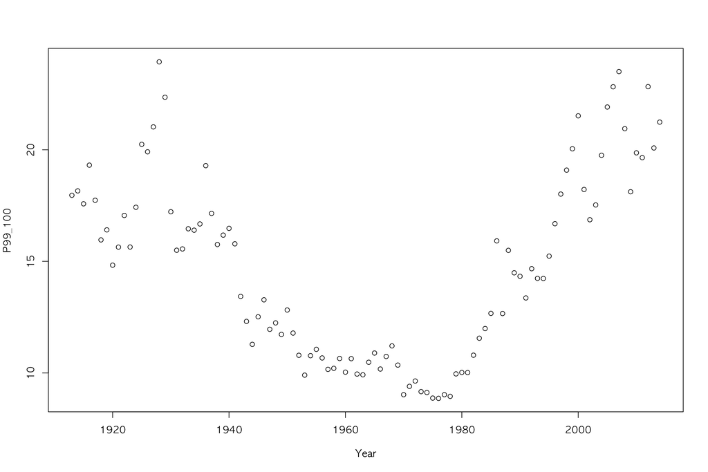

```r
plot(P99_100~Year, data=US.top.income.shares.14)
```

최소한의 정보를 주기 위하여 각 자료의 최대값, 최소값을 고려하여 y-축의 범위를 `ylim=c(5,25)`로 설정하고, x-축의 눈금은 비워둔다. 점들을 선으로 이어주고, 점은 다시 삼각형 모양으로 바꾼다.

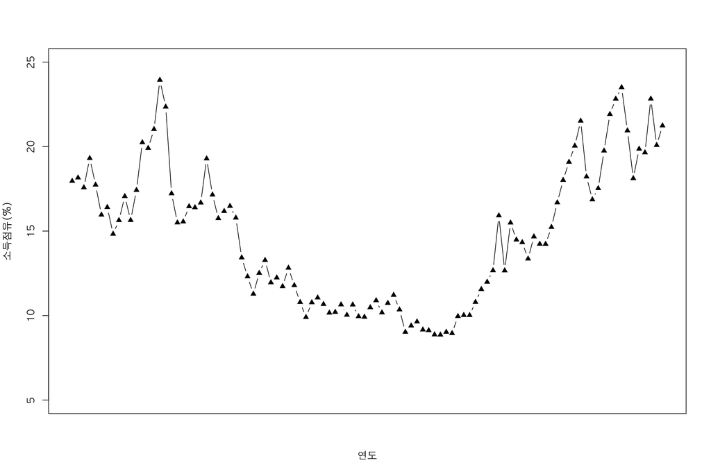

```r
plot(P99_100~Year,data=US.top.income.shares.14, xlab="연도", ylab="소득점유(%)", ylim=c(5,25), xaxt="n", type="b", pch=17)
```

이제 x-축에는 연도를 10년 단위로 표시하고, `lines()`를 이용하여 차상위4%와 차차상위5%의 소득 점유율 변화를 함께 그린다.

도표의 가독성을 높이기 위하여 x-축과 y-축을 가로지르는 격자를 설치한다.

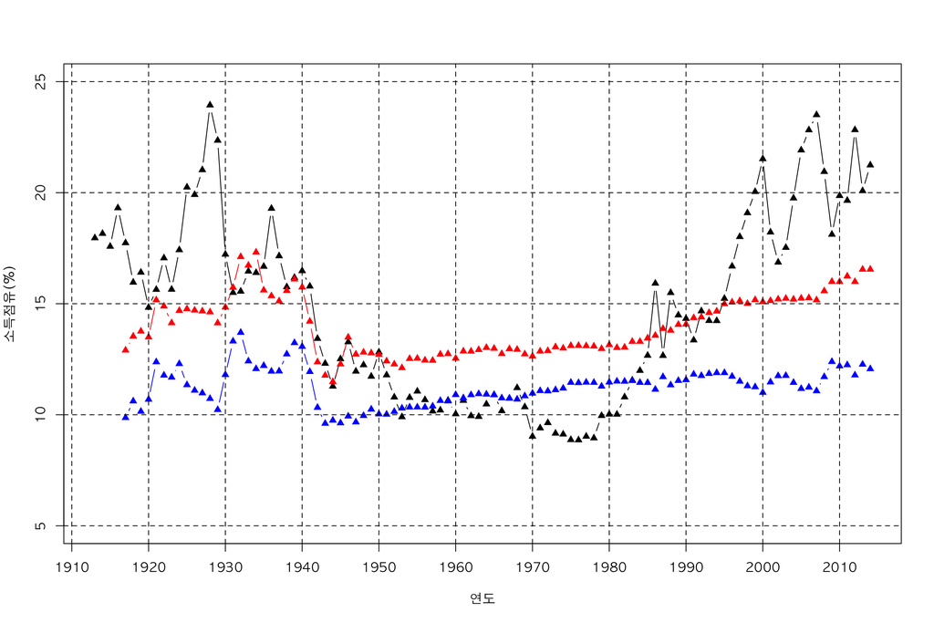

```r
plot(P99_100~Year,data=US.top.income.shares.14, xlab="연도", ylab="소득점유(%)", ylim=c(5,25), xaxt="n", type="b",pch=17)
axis(side=1, at=seq(1910, 2010, by=10), labels=seq(1910, 2010, by=10))
lines(P95_99~Year,data=US.top.income.shares.14,type="b", pch=17, col="red")
lines(P90_95~Year,data=US.top.income.shares.14,type="b", pch=17, col="blue")
abline(h=seq(5,25, by=5), lty=2)
abline(v=seq(1910, 2010, by=10), lty=2)
```

TabFig2014prel.xls의 Table 0 시트에 나와 있는 정보를 활용하여 범례를 만든다.

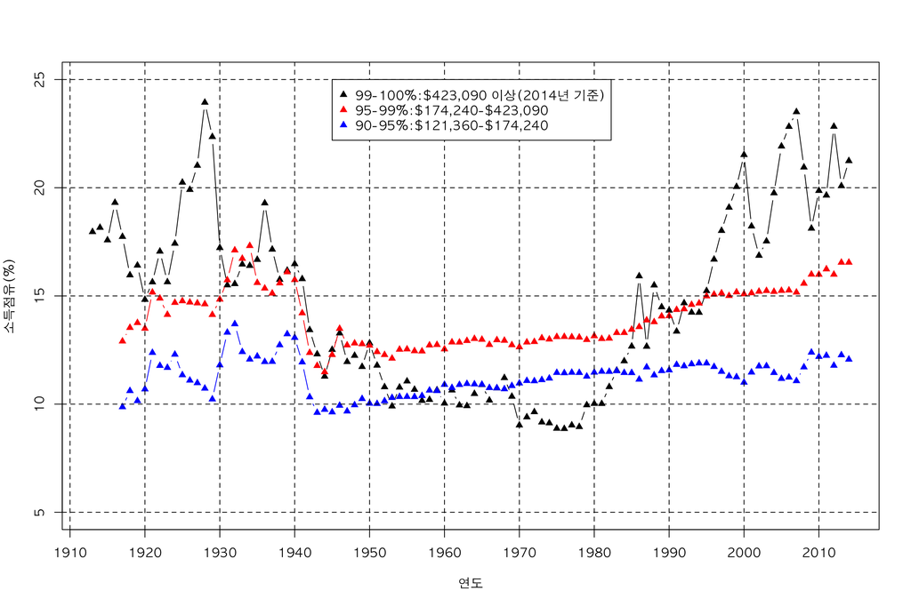

```r
plot(P99_100~Year,data=US.top.income.shares.14, xlab="연도", ylab="소득점유(%)", ylim=c(5,25), xaxt="n", type="b",pch=17)
axis(side=1, at=seq(1910, 2010, by=10), labels=seq(1910, 2010, by=10))
lines(P95_99~Year,data=US.top.income.shares.14,type="b", pch=17, col="red")
lines(P90_95~Year,data=US.top.income.shares.14,type="b", pch=17, col="blue")
abline(h=seq(5,25, by=5), lty=2)
abline(v=seq(1910, 2010, by=10), lty=2)
legend(x=1945, y=25, legend=c("99-100%:$423,090 이상(2014년 기준)","95-99%:$174,240-$423,090","90-95%:$121,360-$174,240"), pch=17, col=c("black", "red", "blue"))
```

메인 타이틀을 입력하고, 상위1%의 소득점유율이 최고에 달했던 연도를 표시한다.

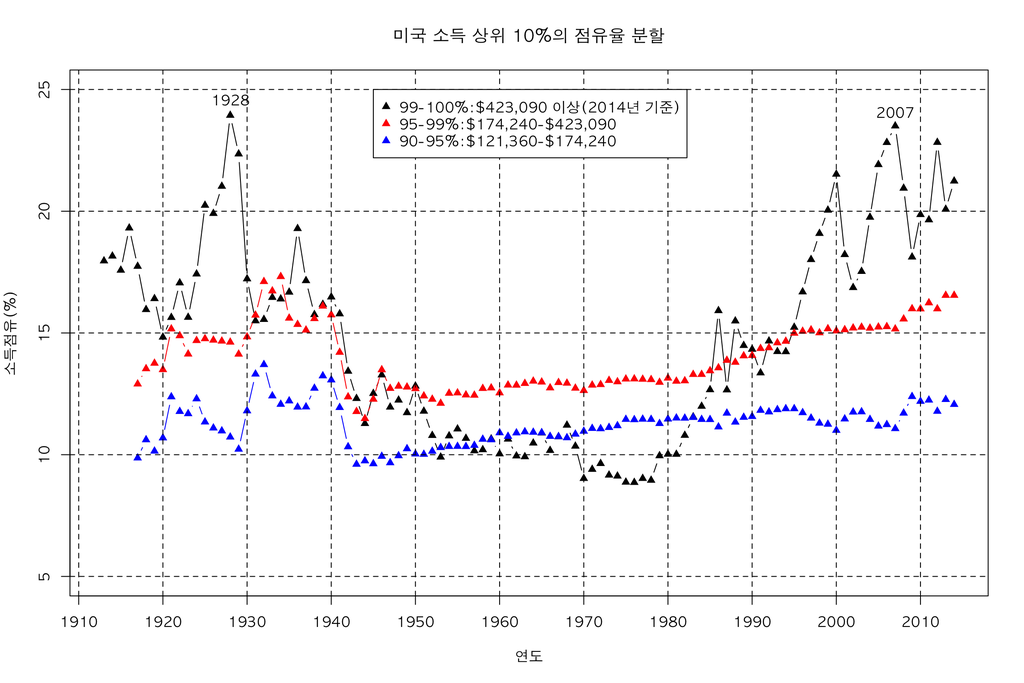

```r
plot(P99_100~Year,data=US.top.income.shares.14, xlab="연도", ylab="소득점유(%)", ylim=c(5,25), xaxt="n", type="b",pch=17)
axis(side=1, at=seq(1910, 2010, by=10), labels=seq(1910, 2010, by=10))
lines(P95_99~Year,data=US.top.income.shares.14,type="b", pch=17, col="red")
lines(P90_95~Year,data=US.top.income.shares.14,type="b", pch=17, col="blue")
abline(h=seq(5,25, by=5), lty=2)
abline(v=seq(1910, 2010, by=10), lty=2)
legend(x=1945, y=25, legend=c("99-100%:$423,090 이상(2014년 기준)","95-99%:$174,240-$423,090","90-95%:$121,360-$174,240"), pch=17, col=c("black", "red", "blue"))
title(main="미국 소득 상위 10%의 점유율 분할")
text(x=c(1928, 2007), y=c(24, 23.5), labels=c("1928", "2007"), pos=3)
```

역사적으로 각 시기를 어떻게 부르고 있는지 텍스트를 추가한다.

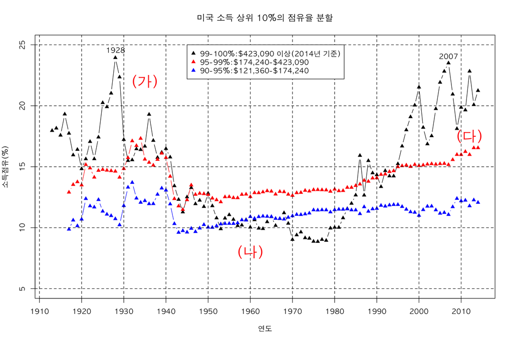

```r
plot(P99_100~Year,data=US.top.income.shares.14, xlab="연도", ylab="소득점유(%)", ylim=c(5,25), xaxt="n", type="b",pch=17)
axis(side=1, at=seq(1910, 2010, by=10), labels=seq(1910, 2010, by=10))
lines(P95_99~Year,data=US.top.income.shares.14,type="b", pch=17, col="red")
lines(P90_95~Year,data=US.top.income.shares.14,type="b", pch=17, col="blue")
abline(h=seq(5,25, by=5), lty=2)
abline(v=seq(1910, 2010, by=10), lty=2)
legend(x=1945, y=25, legend=c("99-100%:$423,090 이상(2014년 기준)","95-99%:$174,240-$423,090","90-95%:$121,360-$174,240"), pch=17, col=c("black", "red", "blue"))
title(main="미국 소득 상위 10%의 점유율 분할")
text(x=c(1928, 2007), y=c(24, 23.5), labels=c("1928", "2007"), pos=3)
text(x=1935, y=22, label="(가)", cex=2.0, col="red")
text(x=1960, y=8, label="(나)", cex=2.0, col="red")
text(x=2012, y=17.5, label="(다)", cex=2.0, col="red")
```

## ggplot

### Data

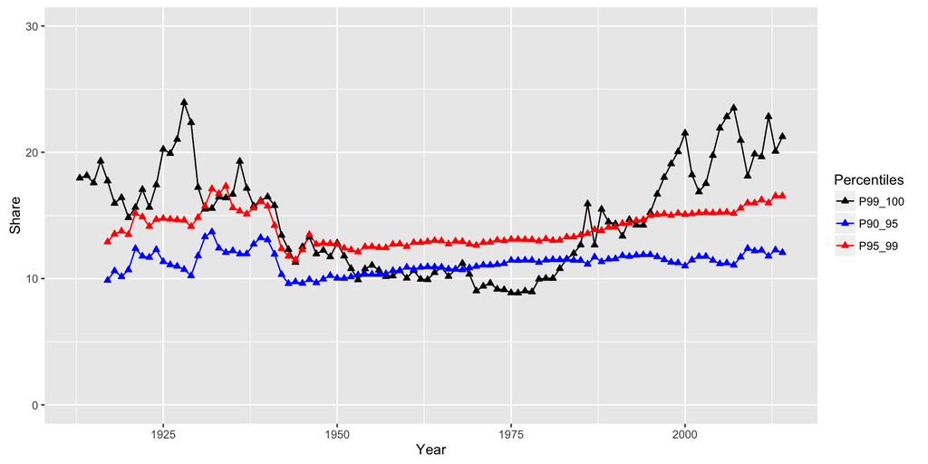

```r
library(reshape2)
data.1_10 <- US.top.income.shares.14[c("Year", "P99_100", "P90_95", "P95_99")]
data.1_10.melt <- melt(data.1_10, id.vars = "Year", measure.vars = c("P99_100", "P90_95", "P95_99"), variable.name = "Percentiles", value.name = "Share")
library(ggplot2)
ggplot(data.1_10.melt, aes(x = Year, y = Share, colour = Percentiles)) + geom_line(na.rm = TRUE) + geom_point(shape=24, aes(fill = Percentiles), na.rm = TRUE) + ylim(0, 30) + scale_colour_manual(values = c("black", "blue", "red")) + scale_fill_manual(values = c("black", "blue", "red"))
```

## 뒷 정리

```r
save.image("US_top_income_share_2014.rda")
```